# Clinical Drug Trial Report: Drug Safety Analysis

Tiffany Nwanne

2025-05-16

# Executive Summary

This report presents an analysis of a clinical drug trial aimed at evaluating the safety profile of a candidate drug compared to a placebo. Key endpoints include the incidence of adverse effects and their severity.

# I. Introduction

## Background

Understanding the safety profile of new pharmaceuticals is essential before clinical approval. This study examines adverse events reported by participants in a randomized trial.

## Objective

To compare the incidence and severity of adverse effects between participants who received the trial drug and those who received a placebo.

# II. Methods

## Study Design

This is a two-arm randomized controlled trial comparing a candidate drug with a placebo.

## Participants

Participant-level data includes demographic variables (e.g., sex), treatment group assignment, and outcomes such as number and presence of adverse effects.

## Endpoints

- **Primary:** Incidence of adverse effects (binary)
- **Secondary:** Number of reported adverse effects

## Statistical Methods

- Descriptive statistics and visualization
- Chi-squared test for comparing proportions
- Mann-Whitney U test for severity comparisons

# III. Results

## 1. Data Import

```r
df <- read_csv("drug_safety.csv")
```

## 2. Baseline Data Exploration

```r
str(df)
```

```
## spc_tbl_ [16,103 × 8] (S3: spec_tbl_df/tbl_df/tbl/data.frame)
##  $ age            : num [1:16103] 62 62 62 62 62 62 62 62 69 69 ...
##  $ sex            : chr [1:16103] "male" "male" "male" "male" ...
##  $ trx            : chr [1:16103] "Drug" "Drug" "Drug" "Drug" ...
##  $ week           : num [1:16103] 0 1 12 16 2 20 4 8 0 1 ...
##  $ wbc            : num [1:16103] 7.3 NA 5.6 NA 6.6 ...
##  $ rbc            : num [1:16103] 5.1 NA 5 NA 5.1 ...
##  $ adverse_effects: chr [1:16103] "No" "No" "No" "No" ...
##  $ num_effects    : num [1:16103] 0 0 0 0 0 1 1 1 0 0 ...
##  - attr(*, "spec")=
##   .. cols(
##   ..   age = col_double(),
##   ..   sex = col_character(),
##   ..   trx = col_character(),
##   ..   week = col_double(),
##   ..   wbc = col_double(),
##   ..   rbc = col_double(),
##   ..   adverse_effects = col_character(),
##   ..   num_effects = col_double()
##   .. )
##  - attr(*, "problems")=<externalptr>
```

```r
summary(df)
```

```
##       age            sex                trx                 week
##  Min.   :39.00   Length:16103       Length:16103       Min.   : 0.000
##  1st Qu.:58.00   Class :character   Class :character   1st Qu.: 1.000
##  Median :65.00   Mode  :character   Mode  :character   Median : 4.000
##  Mean   :64.12                                         Mean   : 7.741
##  3rd Qu.:71.00                                         3rd Qu.:12.000
##  Max.   :84.00                                         Max.   :20.000
##
##       wbc              rbc        adverse_effects     num_effects
##  Min.   : 1.800   Min.   :2.100   Length:16103       Min.   :0.0000
##  1st Qu.: 6.000   1st Qu.:4.400   Class :character   1st Qu.:0.0000
##  Median : 7.100   Median :4.700   Mode  :character   Median :0.0000
##  Mean   : 7.341   Mean   :4.673                      Mean   :0.1016
##  3rd Qu.: 8.400   3rd Qu.:5.000                      3rd Qu.:0.0000
##  Max.   :26.500   Max.   :7.600                      Max.   :3.0000
##  NA's   :6975     NA's   :6976
```

```r
head(df)
```

```
## # A tibble: 6 × 8
##     age sex   trx    week   wbc   rbc adverse_effects num_effects
##   <dbl> <chr> <chr> <dbl> <dbl> <dbl> <chr>                 <dbl>
## 1    62 male  Drug      0  7.30  5.10 No                        0
## 2    62 male  Drug      1 NA    NA    No                        0
## 3    62 male  Drug     12  5.60  5    No                        0
## 4    62 male  Drug     16 NA    NA    No                        0
## 5    62 male  Drug      2  6.60  5.10 No                        0
## 6    62 male  Drug     20 NA    NA    Yes                       1
```

```r
colSums(is.na(df))
```

```
##             age             sex             trx            week             wbc
##               0               0               0               0            6975
##             rbc adverse_effects     num_effects
##            6976               0               0
```

## 3. Data Cleaning

```r
df <- df |> select(-wbc, -rbc)

# Basic frequency tables
table(df$sex)
```

```
##
## female   male
##   3775  12328
```

```r
table(df$trx)
```

```
##
##    Drug Placebo
##   10727    5376
```

```r
table(df$adverse_effects)
```

```
##
##    No   Yes
## 14567  1536
```

```r
# Create binary outcome
df$adverse_binary <- ifelse(df$adverse_effects == "Yes", 1, 0)
```

## 4. Primary Endpoint Analysis: Adverse Effect Rate

```r
# Overall adverse rate
mean(df$adverse_binary)
```

```
## [1] 0.09538595
```

```r
# By treatment group
df |> group_by(trx) |> summarise(adverse_rate = mean(adverse_binary))
```

```
## # A tibble: 2 × 2
##   trx     adverse_rate
##   <chr>          <dbl>
## 1 Drug          0.0955
## 2 Placebo       0.0952
```

### Figure 1: Adverse Effect Rate by Treatment Group

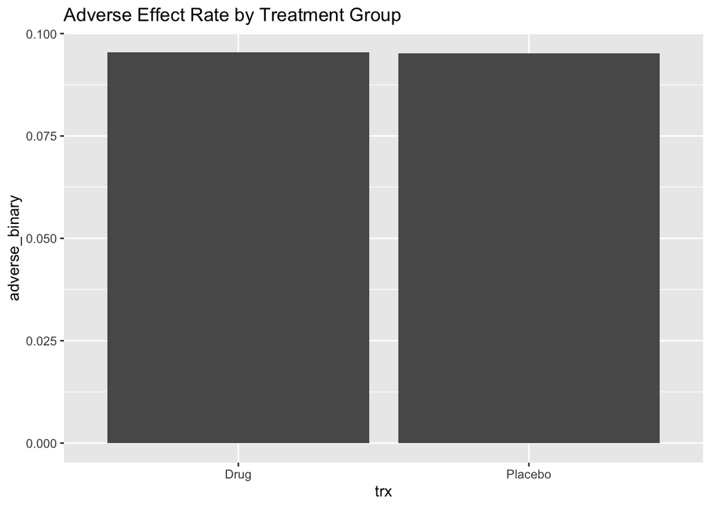

```r
ggplot(df, aes(x = trx, y = adverse_binary)) +
  stat_summary(fun = mean, geom = "bar") +
  ggtitle("Adverse Effect Rate by Treatment Group")
```

## 5. Secondary Endpoint: Severity of Adverse Effects

### Figure 2: Number of Adverse Effects by Group

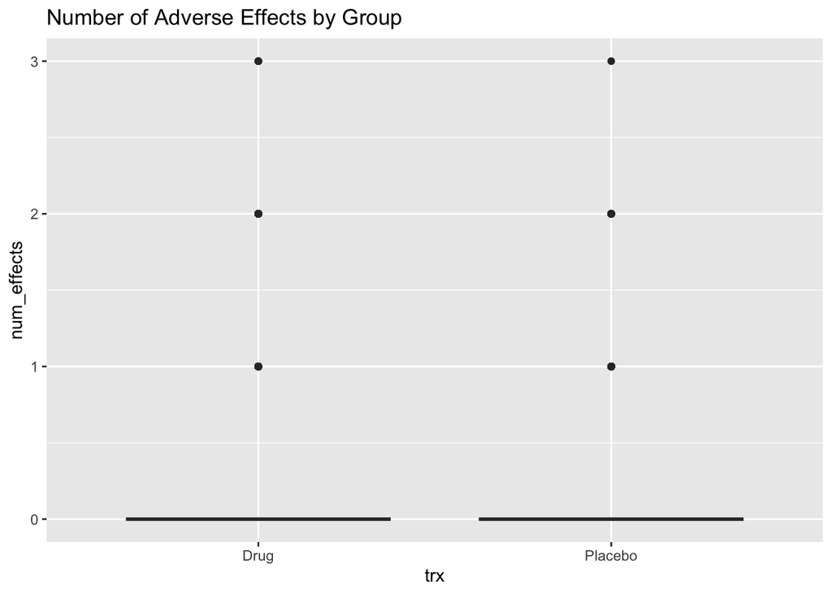

```r
ggplot(df, aes(x = trx, y = num_effects)) +
  geom_boxplot() +
  ggtitle("Number of Adverse Effects by Group")
```

## 6. Statistical Testing

### Chi-squared Test (Adverse Effect Incidence)

```r
table1 <- table(df$trx, df$adverse_binary)
chisq.test(table1)
```

```
##
##  Pearson's Chi-squared test with Yates' continuity correction
##
## data:  table1
## X-squared = 0.0002814, df = 1, p-value = 0.9866
```

### Mann-Whitney U Test (Effect Severity)

```r
drug <- df$num_effects[df$trx == "Drug"]
placebo <- df$num_effects[df$trx == "Placebo"]
wilcox.test(drug, placebo)
```

```
##
##  Wilcoxon rank sum test with continuity correction
##
## data:  drug and placebo
## W = 28844703, p-value = 0.9407
## alternative hypothesis: true location shift is not equal to 0
```

# IV. Discussion

# V. Conclusion

# VI. Appendices

## Code: Saving Outputs

```r
write.csv(df, "cleaned_drug_safety.csv", row.names = FALSE)
saveRDS(df, "cleaned_drug_safety.rds")

plot1 <- ggplot(df, aes(x = trx, y = adverse_binary)) +
  stat_summary(fun = mean, geom = "bar") +
  ggtitle("Adverse Effect Rate by Treatment Group")

ggsave("adverse_rate_by_group.png", plot = plot1, width = 6, height = 4, dpi = 300)
```